# Hurricane Floyd Stream Gage Analysis

We want to evaluate the discharge at multiple stream gage stations in the path of Hurricane Floyd (1999). First, we obtain stream gage stations by county using the following code:

```r
library(dplyr)
stream_stations <- function(fips, date_min, date_max, fraction_coverage = NULL){
  fips <- paste(fips, collapse = ",")
  url <- paste0("http://waterservices.usgs.gov/nwis/site/?format=rdb&countyCd=",
                fips, "&startDT=", date_min, "&endDT=", date_max,
                "&outputDataTypeCd=dv&parameterCd=00060&siteType=ST")

  df <- read.table(url, sep = "\t", comment.char = "#", header = TRUE)
  df <- df[-1, ]

  df$begin_date <- lubridate::ymd(df$begin_date)
  df$end_date <- lubridate::ymd(df$end_date)

  df <- dplyr::mutate(df, date_range = df$end_date - df$begin_date)
  df$date_range <- as.numeric(df$date_range)
  df$count_nu <- as.numeric(df$count_nu)

  df <- dplyr::mutate(df, perc_coverage = (count_nu/date_range))
  if(is.null(fraction_coverage)){
    fraction_coverage <- min(df$perc_coverage)
  }

  df <- filter(df, perc_coverage >= fraction_coverage)

  vec <- as.character(unique(df$site_no))
  return(vec)
}
stream_stations("37019", "1987-01-01", "2014-12-31", fraction_coverage=NULL)
```

```
## [1] "02105900" "02109500"
```

```r
# [1] "02105900" "02109500"
```

Here we use use a fips code corresponding to Brunswick County, NC near Wilmington, NC. The code outputs two stream gage site numbers, 02105900 and 02109500. Next, we find the 95th percentile of flow at these stations to define a flood. The function used below is only able to output percentile values of discharge up to the 95th percentile. More analysis will have to be performed to find values for the 99th or other more specific percentile discharges in order to define “flooding”.

```r
buildURL <- function(siteNumber) {
  url <- "http://waterservices.usgs.gov/nwis/stat/?format=rdb&sites="
  url <- paste0(url, siteNumber, "&statReportType=daily&statTypeCd=p95")
  return(url)}
buildURL("02105900")
```

```
## [1] "http://waterservices.usgs.gov/nwis/stat/?format=rdb&sites=02105900&statReportType=daily&statTypeCd=p95"
```

The generated url for site 02105900 includes 95th percentile values for parameters other than discharge. To clean this up, run the following code to ensure that only the discharge values are presented (ie values for parameter_cd 00060).

```r
readNWISstat <- function (siteNumber, parameterCd)
{
  url <- buildURL(siteNumber)
  data <- read.table(url,sep="\t",header=T)
  #remove first row
  data <- data[2:length(data[,1]),]
  #keep only discharge values
  data <- data[data$parameter_cd==parameterCd,]

  return(data)
}
```

Running this code will cause R to output all the available 95th percentile values for discharge at staiton 02105900. These percentile values are listed by day and month. This means that we can find the 95th percentile of discharge on all days encompassing Hurricane Floyd (1999) and compare the 95th percentile discharges to the actual discharges during Hurricane Floyd (1999).

```r
library(waterData)
site.02105900.floyd.discharge <- importDVs("02105900", code="00060", stat="00003", sdate="1999-09-01", edate="1999-09-26")
site.02105900.floyd.discharge
```

```
##       staid  val      dates qualcode
## 1  02105900   77 1999-09-01        A
## 2  02105900   43 1999-09-02        A
## 3  02105900   27 1999-09-03        A
## 4  02105900   20 1999-09-04        A
## 5  02105900   16 1999-09-05        A
## 6  02105900   15 1999-09-06        A
## 7  02105900   16 1999-09-07        A
## 8  02105900   16 1999-09-08        A
## 9  02105900   16 1999-09-09        A
## 10 02105900   27 1999-09-10        A
## 11 02105900   32 1999-09-11        A
## 12 02105900   20 1999-09-12        A
## 13 02105900   14 1999-09-13        A
## 14 02105900   12 1999-09-14        A
## 15 02105900 1000 1999-09-15      A e
## 16 02105900 3000 1999-09-16      A e
## 17 02105900 2600 1999-09-17      A e
## 18 02105900 1600 1999-09-18      A e
## 19 02105900 1200 1999-09-19      A e
## 20 02105900  900 1999-09-20      A e
## 21 02105900  850 1999-09-21      A e
## 22 02105900  750 1999-09-22      A e
## 23 02105900  650 1999-09-23      A e
## 24 02105900  580 1999-09-24      A e
## 25 02105900  540 1999-09-25      A e
## 26 02105900  520 1999-09-26      A e
```

We can also build a url with site.02105900.floyd.discharge. Note that the discharges are denoted with a qualcode. Qualcode “A” denotes approved for publication, qualcode “e” means that the value has been edited or estimated be USGS personnel. A full list of qualcodes is available [here](http://help.waterdata.usgs.gov/codes-and-parameters/daily-value-qualification-code-dv_rmk_cd).

```r
site.02105900.floyd.url <- tellMeURL("02105900", code="00060", stat="00003", sdate="1999-09-01", edate="1999-09-26")
site.02105900.floyd.url
```

```
## [1] "http://waterservices.usgs.gov/nwis/dv?site=02105900&parameterCd=00060&statCd=00003&startDt=1999-09-01&endDt=1999-09-26"
```

Plot the Floyd data along with the percentile data to get a visual representation of potential flooding.

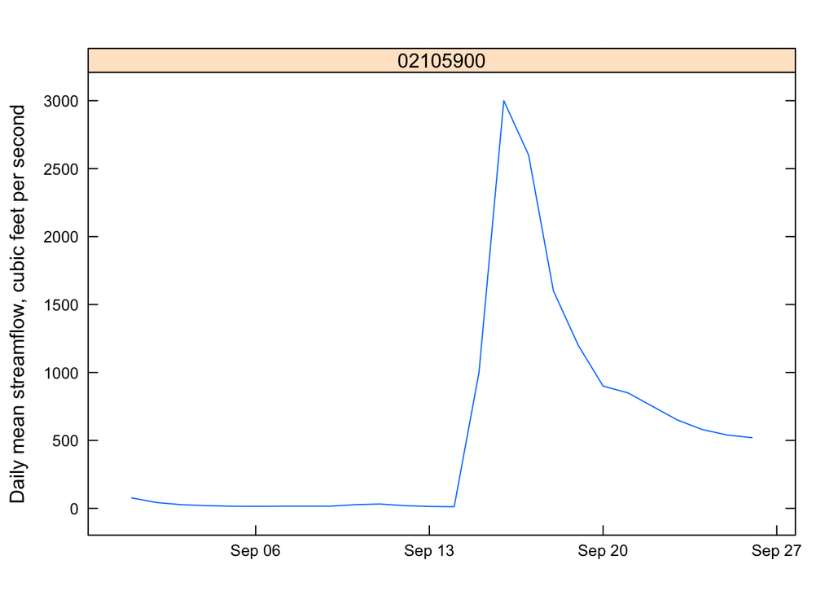

```r
# Create a plot of the daily discharge data using the waterData function plotParam. This step is not strictly necessary
floyd.plot <- plotParam(site.02105900.floyd.discharge)
print(floyd.plot)
```

```r
# Sort out all percentile values for September
library(knitr)
site.02105900.percentile.data <- readNWISstat("02105900", "00060")
kable(site.02105900.percentile.data[245:275, ])
```

[output not shown]

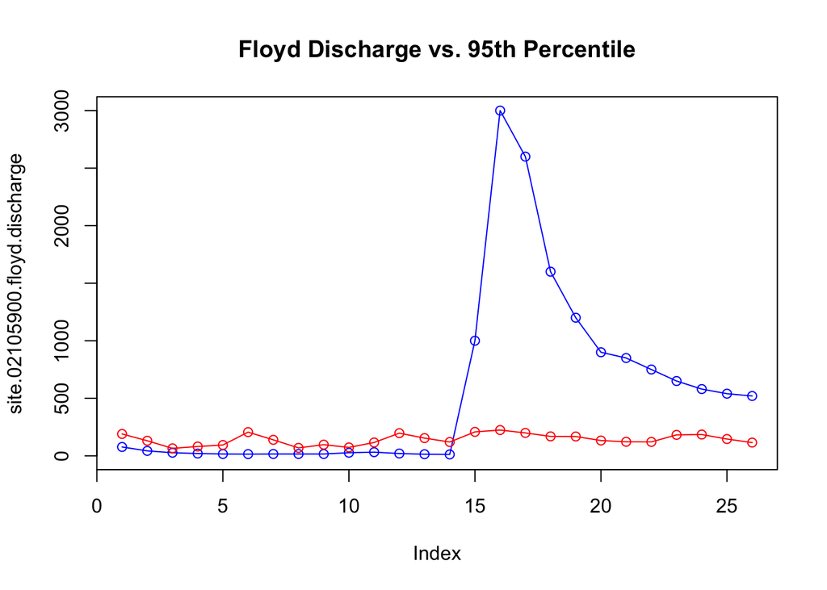

```r
# Creating data set manually for September 1-26, find better way to do this
site.02105900.percentile.data <- as.numeric(site.02105900.percentile.data[245:270, "p95_va"])

site.02105900.floyd.discharge <- c(77, 43, 27, 20, 16, 15, 16, 16, 16, 27, 32, 20, 14, 12, 1000, 3000, 2600, 1600, 1200, 900, 850, 750, 650, 580, 540, 520)

# Create plot with both data sets
plot(site.02105900.floyd.discharge, type="o", col="blue", ylim=c(0,3000))
lines(site.02105900.percentile.data, type="o", col="red")
title(main="Floyd Discharge vs. 95th Percentile")
```

However, not all stream staitons have reliable stream gage data. This gage (02093229) in New Hanover County, NC (also near Wilmington, NC) does not have reliable data.

```r
library(dplyr)
stream_stations("37129", "1987-01-01", "2014-12-31", fraction_coverage=NULL)
```

```
## [1] "02093229"
```

```r
# [1] "02093229"
buildURL("02093229")
```

```
## [1] "http://waterservices.usgs.gov/nwis/stat/?format=rdb&sites=02093229&statReportType=daily&statTypeCd=p95"
```

```r
# The url http://waterservices.usgs.gov/nwis/stat/?format=rdb&sites=02093229&statReportType=daily&statTypeCd=p95 does not display any 95th percentile flow values.
```

We also want to examine flooding in areas more indirectly affected by Hurricane Floyd. Below is the code for stream stations on in or near the Raleigh-Durham area.

```r
# Wake County
stream_stations("37183", "1987-01-01", "2014-12-31", fraction_coverage=NULL)
```

```
##  [1] "0208718210"      "02087183"        "0208721055"
##  [4] "0208721290"      "0208725600"      "0208726005"
##  [7] "0208726100"      "0208726835"      "0208726990"
## [10] "02087275"        "0208730025"      "02087322"
## [13] "02087324"        "0208732534"      "0208732810"
## [16] "0208732885"      "0208734220"      "0208735012"
## [19] "0208735550"      "02087359"        "0208739674"
## [22] "0208739678"      "0208741400"      "02087580"
## [25] "0208758850"      "0208762750"      "0208762755"
## [28] "02088383"        "0209782609"      "354347078401501"
## [31] "354349078402801" "354355078401401"
```

```r
#[1] "0208718210"      "02087183"        "0208721055"      "0208721290"      "0208725600"      "0208726005"
#[7] "0208726100"      "0208726835"      "0208726990"      "02087275"        "0208730025"      "02087322"
#[13] "02087324"        "0208732534"      "0208732810"      "0208732885"      "0208734220"      "0208735012"
#[19] "0208735550"      "02087359"        "0208739674"      "0208739678"      "0208741400"      "02087580"
#[25] "0208758850"      "0208762750"      "0208762755"      "02088383"        "0209782609"      "354347078401501"
#[31] "354349078402801" "354355078401401"

# Durham County
stream_stations("37063", "1987-01-01", "2014-12-31", fraction_coverage=NULL)
```

```
##  [1] "02085070"   "02085079"   "0208521324" "02085220"   "0208524090"
##  [6] "0208524975" "02085500"   "02086000"   "02086500"   "0208650112"
## [11] "0208675010" "02086849"   "0208700780" "0209722970" "02097280"
## [16] "02097314"   "0209741955"
```

```r
#[1] "02085070"   "02085079"   "0208521324" "02085220"   "0208524090" "0208524975" "02085500"   "02086000"
#[9] "02086500"   "0208650112" "0208675010" "02086849"   "0208700780" "0209722970" "02097280"   "02097314"
#[17] "0209741955"

# Johnston County
stream_stations("37101", "1987-01-01", "2014-12-31", fraction_coverage=NULL)
```

```
## [1] "02087500"   "02087570"   "0208773375" "02088000"   "02088470"
## [6] "02088500"
```

```r
#[1] "02087500"   "02087570"   "0208773375" "02088000"   "02088470"   "02088500"

# Orange County
stream_stations("37135", "1987-01-01", "2014-12-31", fraction_coverage=NULL)
```

```
## [1] "02084909"   "02085000"   "02096846"   "0209691590" "0209691611"
## [6] "0209734440" "0209736050" "02097464"   "02097517"
```

```r
#[1] "02084909"   "02085000"   "02096846"   "0209691590" "0209691611" "0209734440" "0209736050" "02097464"   "02097517"

# Franklin County
stream_stations("37069", "1987-01-01", "2014-12-31", fraction_coverage=NULL)
```

```
## [1] "02081747" "02082731"
```

```r
#[1] "02081747" "02082731"

# Nash County (closer to Rocky Mount, NC)
stream_stations("37127", "1987-01-01", "2014-12-31", fraction_coverage=NULL)
```

```
## [1] "02081942"   "0208250410" "02082506"   "02082770"
```

```r
#[1] "02081942"   "0208250410" "02082506"   "02082770"

# Chatham County
stream_stations("37037", "1987-01-01", "2014-12-31", fraction_coverage=NULL)
```

```
##  [1] "02096960"   "0209782150" "02098198"   "02098200"   "02098206"
##  [6] "0210166029" "02101726"   "02101800"   "02102094"   "02102192"
```

```r
#[1] "02096960"   "0209782150" "02098198"   "02098200"   "02098206"   "0210166029" "02101726"   "02101800"   "02102094"
#[10] "02102192"
```

We also want to find data from stations near Charlotte, NC.

```r
# Mecklenburg County
stream_stations("37119", "1987-01-01", "2014-12-31", fraction_coverage=NULL)
```

```
## character(0)
```

```r
# Receive character(0) as output, try changing boundary dates

stream_stations("37119", "1998-01-01", "2000-12-31", fraction_coverage=NULL)
```

```
##  [1] "0212414900" "02142651"   "0214266000" "02142900"   "0214291555"
##  [6] "0214295600" "0214620805" "02146211"   "0214627970" "02146285"
## [11] "02146300"   "02146315"   "02146348"   "02146381"   "02146409"
## [16] "0214642825" "0214643840" "0214645022" "02146470"   "0214650690"
## [21] "02146507"   "02146530"   "0214655255" "02146562"   "0214657975"
## [26] "02146600"   "0214666925" "02146670"   "0214669980" "02146700"
## [31] "02146750"   "0214677974" "0214678175"
```

```r
#[1] "0212414900" "02142651"   "0214266000" "02142900"   "0214291555" "0214295600" "0214620805" "02146211"   "0214627970"
#[10] "02146285"   "02146300"   "02146315"   "02146348"   "02146381"   "02146409"   "0214642825" "0214643840" "0214645022"
#[19] "02146470"   "0214650690" "02146507"   "02146530"   "0214655255" "02146562"   "0214657975" "02146600"   "0214666925"
#[28] "02146670"   "0214669980" "02146700"   "02146750"   "0214677974" "0214678175"

# Gaston County
stream_stations("37071", "1987-01-01", "2014-12-31", fraction_coverage=NULL)
```

```
## [1] "0214399575" "0214399580" "02144000"   "02145000"
```

```r
#[1] "0214399575" "0214399580" "02144000"   "02145000"
```

Find data from stream gages in Virginia along floyd path

```r
# Southhampton County
stream_stations("51175", "1987-01-01", "2014-12-31", fraction_coverage=NULL)
```

```
## [1] "02047000" "02047100" "02049500" "02052090"
```

```r
#[1] "02047000" "02047100" "02049500" "02052090"
```

Evaluate whether flooding occured at more inland sites -> choose stations from Raleigh-Durham and Charlotte areas that have available 95th percentile data.

```r
# From Wake County
buildURL("0208718210")
```

```
## [1] "http://waterservices.usgs.gov/nwis/stat/?format=rdb&sites=0208718210&statReportType=daily&statTypeCd=p95"
```

```r
#No 95th percentile values, choose new station

buildURL("02087324")
```

```
## [1] "http://waterservices.usgs.gov/nwis/stat/?format=rdb&sites=02087324&statReportType=daily&statTypeCd=p95"
```

```r
#Has 95th percentile values

#Clean up data to exclude parameter codes other than "00060"
readNWISstat("02087324", "00060")
```

[output not shown]

[output cut: 719 more lines]

Follow the same process as beofre to create a table of the 95th percentile flow values and the average daily discharge for Hurricane Floyd.

```r
library(waterData)
site.02087324.floyd.discharge <- importDVs("02087324", code="00060", stat="00003", sdate="1999-09-01", edate="1999-09-26")
site.02087324.floyd.discharge
```

```
##       staid  val      dates qualcode
## 1  02087324   28 1999-09-01        A
## 2  02087324   23 1999-09-02        A
## 3  02087324   19 1999-09-03        A
## 4  02087324  151 1999-09-04        A
## 5  02087324 2280 1999-09-05        A
## 6  02087324 3030 1999-09-06        A
## 7  02087324 1800 1999-09-07        A
## 8  02087324 1300 1999-09-08        A
## 9  02087324  940 1999-09-09        A
## 10 02087324  582 1999-09-10        A
## 11 02087324  387 1999-09-11        A
## 12 02087324  229 1999-09-12        A
## 13 02087324  136 1999-09-13        A
## 14 02087324   91 1999-09-14        A
## 15 02087324  702 1999-09-15        A
## 16 02087324 6060 1999-09-16        A
## 17 02087324 2290 1999-09-17        A
## 18 02087324 1710 1999-09-18        A
## 19 02087324 1440 1999-09-19        A
## 20 02087324 1040 1999-09-20        A
## 21 02087324  807 1999-09-21        A
## 22 02087324 1040 1999-09-22        A
## 23 02087324  478 1999-09-23        A
## 24 02087324  270 1999-09-24        A
## 25 02087324  167 1999-09-25        A
## 26 02087324  112 1999-09-26        A
```

```r
library(xtable)
site.02087324.percentile.data <- readNWISstat("02087324", "00060")
head(site.02087324.percentile.data)
```

```
##   agency_cd  site_no parameter_cd dd_nu loc_web_ds month_nu day_nu
## 2      USGS 02087324        00060     2                   1      1
## 3      USGS 02087324        00060     2                   1      2
## 4      USGS 02087324        00060     2                   1      3
## 5      USGS 02087324        00060     2                   1      4
## 6      USGS 02087324        00060     2                   1      5
## 7      USGS 02087324        00060     2                   1      6
##   begin_yr end_yr count_nu p95_va
## 2     1991   2015       25    422
## 3     1991   2015       25    377
## 4     1991   2015       25   1010
## 5     1991   2015       25   1080
## 6     1991   2015       25    708
## 7     1991   2015       25    617
```

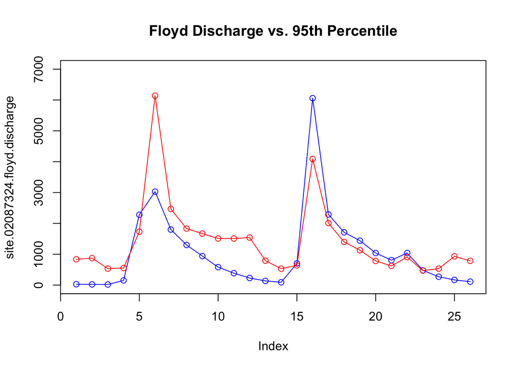

```r
# xtable(site.02105900.percentile.data[245:275, ])

site.02087324.percentile.data <- c(837, 873, 535, 553, 1730, 6140, 2470, 1830, 1670, 1510, 1510, 1540, 792, 533, 638, 4090, 2010, 1400, 1130, 783, 622, 908, 470, 533, 932, 787)
site.02087324.floyd.discharge <- c(28, 23, 19, 151, 2280, 3030, 1800, 1300, 940, 582, 387, 229, 136, 91, 702, 6060, 2290, 1710, 1440, 1040, 807, 1040, 478, 270, 167, 112)

plot(site.02087324.floyd.discharge, type="o", col="blue", ylim=c(0,7000))
lines(site.02087324.percentile.data, type="o", col="red")
title(main="Floyd Discharge vs. 95th Percentile")
```

```r
# Red is percentile flow, blue is actual recorded flow
```

Using this method, it is possible to create a plot for any stream gage station with 95th percentile flow values.

Next, we evaluate a stream gage station in the Charlotte, NC area

```r
# From Mecklenburg County
buildURL("02142651")
```

```
## [1] "http://waterservices.usgs.gov/nwis/stat/?format=rdb&sites=02142651&statReportType=daily&statTypeCd=p95"
```

```r
# No 95th percentile
buildURL("02146300")
```

```
## [1] "http://waterservices.usgs.gov/nwis/stat/?format=rdb&sites=02146300&statReportType=daily&statTypeCd=p95"
```

```r
# Has 95th percentile values

readNWISstat("02146300", "00060")
```

[output not shown]

[output cut: 719 more lines]

```r
library(xtable)
site.02146300.percentile.data <- readNWISstat("02146300", "00060")
xtable(site.02146300.percentile.data[245:275, ])
```

```
## % latex table generated in R 3.3.0 by xtable 1.8-2 package
## % Thu Jun  9 10:55:26 2016
## \begin{table}[ht]
## \centering
## \begin{tabular}{rlllllllllll}
##   \hline
##  & agency\_cd & site\_no & parameter\_cd & dd\_nu & loc\_web\_ds & month\_nu & day\_nu & begin\_yr & end\_yr & count\_nu & p95\_va \\
##   \hline
## 246 & USGS & 02146300 & 00060 & 1 &  & 9 & 1 & 1962 & 2015 & 54 & 50 \\
##   247 & USGS & 02146300 & 00060 & 1 &  & 9 & 2 & 1962 & 2015 & 54 & 57 \\
##   248 & USGS & 02146300 & 00060 & 1 &  & 9 & 3 & 1962 & 2015 & 54 & 240 \\
##   249 & USGS & 02146300 & 00060 & 1 &  & 9 & 4 & 1962 & 2015 & 54 & 197 \\
##   250 & USGS & 02146300 & 00060 & 1 &  & 9 & 5 & 1962 & 2015 & 54 & 215 \\
##   251 & USGS & 02146300 & 00060 & 1 &  & 9 & 6 & 1962 & 2015 & 54 & 146 \\
##   252 & USGS & 02146300 & 00060 & 1 &  & 9 & 7 & 1962 & 2015 & 54 & 569 \\
```

[output cut: 27 more lines]

```r
library(waterData)
site.02146300.floyd.discharge <- importDVs("02146300", code="00060", stat="00003", sdate="1999-09-01", edate="1999-09-26")
site.02146300.floyd.discharge
```

```
##       staid  val      dates qualcode
## 1  02146300 11.0 1999-09-01        A
## 2  02146300  9.2 1999-09-02        A
## 3  02146300  8.6 1999-09-03        A
## 4  02146300  8.4 1999-09-04        A
## 5  02146300 65.0 1999-09-05        A
## 6  02146300 18.0 1999-09-06        A
## 7  02146300 14.0 1999-09-07        A
## 8  02146300 12.0 1999-09-08        A
## 9  02146300 15.0 1999-09-09        A
## 10 02146300 13.0 1999-09-10        A
## 11 02146300  7.7 1999-09-11        A
## 12 02146300  6.6 1999-09-12        A
## 13 02146300  8.2 1999-09-13        A
## 14 02146300  7.9 1999-09-14        A
## 15 02146300 42.0 1999-09-15        A
## 16 02146300 66.0 1999-09-16        A
## 17 02146300  8.6 1999-09-17        A
## 18 02146300  8.4 1999-09-18        A
## 19 02146300  8.7 1999-09-19        A
## 20 02146300  6.9 1999-09-20        A
## 21 02146300 59.0 1999-09-21        A
## 22 02146300 37.0 1999-09-22        A
## 23 02146300  9.9 1999-09-23        A
## 24 02146300  7.9 1999-09-24        A
## 25 02146300  8.2 1999-09-25        A
## 26 02146300  9.1 1999-09-26        A
```

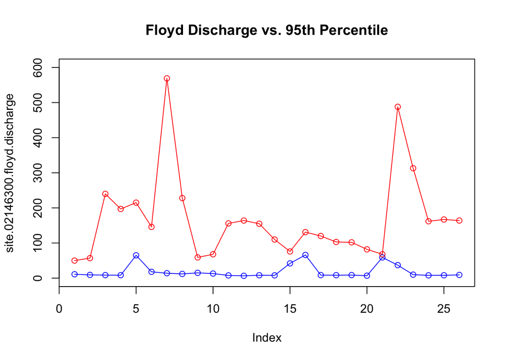

```r
site.02146300.percentile.data <- c(50, 57, 240, 197, 215, 146, 569, 228, 59, 68, 156, 164, 155, 110, 76, 131, 120, 103, 102, 82, 68, 488, 313, 162, 167, 164)
site.02146300.floyd.discharge <- c(11, 9.2, 8.6, 8.4, 65, 18, 14, 12, 15, 13, 7.7, 6.6, 8.2, 7.9, 42, 66, 8.6, 8.4, 8.7, 6.9, 59, 37, 9.9, 7.9, 8.2, 9.1)

plot(site.02146300.floyd.discharge, type="o", col="blue", ylim=c(0,600))
lines(site.02146300.percentile.data, type="o", col="red")
title(main="Floyd Discharge vs. 95th Percentile")
```

```r
# Red is percentile flow, blue is actual recorded flow
```